# Statistical Learning: Final Project

Authors

Sofía Karsaclian (01/1246546)

Elias Heppner (01/1244414)

Andri Rutschmann (01/1246603)

# Data Exploration and Feature Selection

## Exploration

We investigated the data by inspecting summary statistics and plotting histograms of all feature variables. The dataset consists of 569 observations and contains 30 features, consisting of the mean, standard error and worst value of 10 different metrics.

All features are numeric and in essence normally distributed, though many are heavily right-skewed. This is reasonable for the standard error and worst value features as they consist of values close to 0 and thus cannot be left-skewed. It is unclear why many of the mean features are right skewed.

*Figure 1*

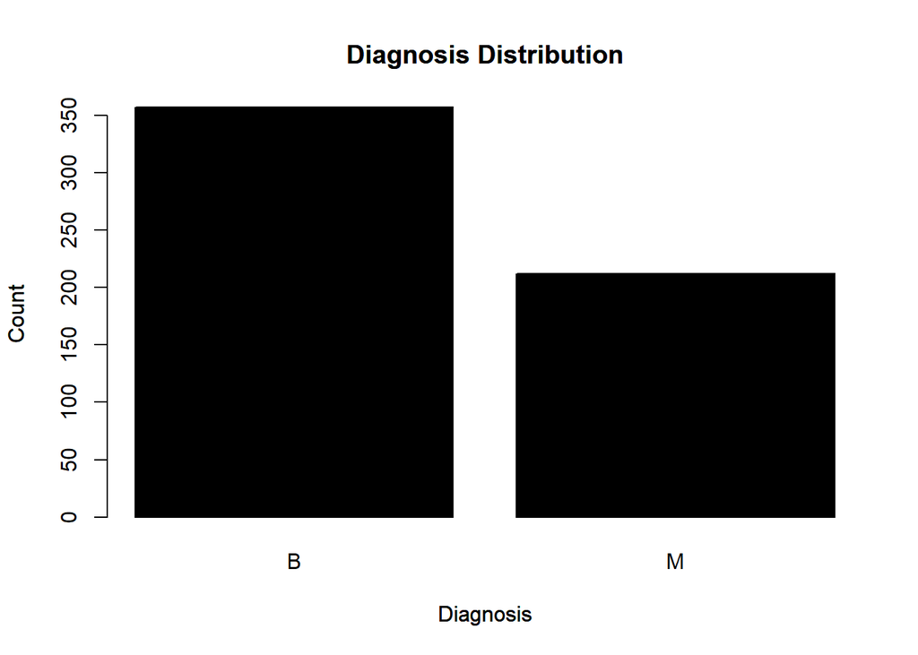

Concerning the target variable, diagnosis, a simple barplot reveals that the dataset is unbalanced. About 37 percent of all observations are malignant, whereas about 63 percent are benign.

## Feature Selection

We investigated both the correlation of all features with the target variable as well as pair-wise correlation between the features.

*Table 1*

| variable | correlation |
| --- | --- |
| texture_mean | 0.4151853 |
| smoothness_mean | 0.3585600 |
| symmetry_mean | 0.3304986 |
| fractal_dimension_mean | -0.0128376 |
| texture_se | -0.0083033 |
| smoothness_se | -0.0670160 |
| compactness_se | 0.2929992 |
| concavity_se | 0.2537298 |
| concave.points_se | 0.4080423 |
| symmetry_se | -0.0065218 |
| fractal_dimension_se | 0.0779724 |
| texture_worst | 0.4569028 |
| smoothness_worst | 0.4214649 |
| symmetry_worst | 0.4162943 |
| fractal_dimension_worst | 0.3238722 |

Inspecting the correlation between the features and the target variable revealed low correlation values (smaller than 0.5) for the features presented in Table 1. A simple logistic regression further revealed a statistically insignificant relation between the target variable and the features shown in Table 2.

*Table 2*

| variable | p_value | significant |
| --- | --- | --- |
| fractal_dimension_mean | 0.7594710 | No |
| texture_se | 0.8430081 | No |
| smoothness_se | 0.1125108 | No |
| symmetry_se | 0.8763827 | No |
| fractal_dimension_se | 0.0705555 | No |

A correlation plot of the feature variables reveals high correlations between some of them. Dropping features with a correlation greater than 0.9. would lead to a reduction by 10 features, greatly reducing the dimensionality of the data.

*Figure 2*

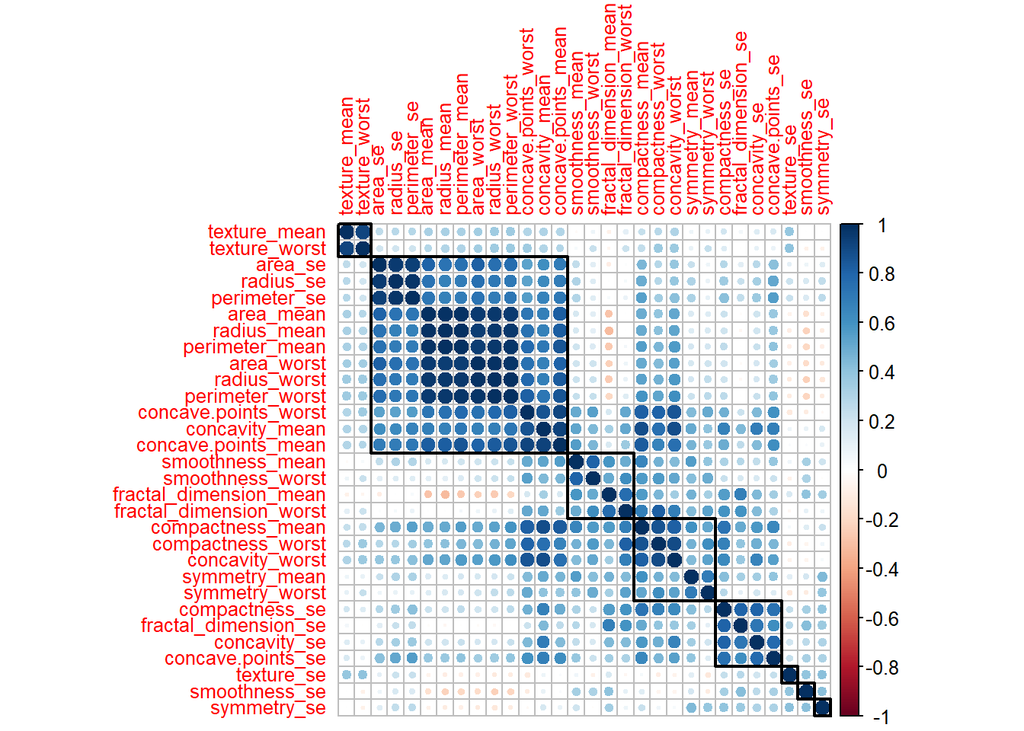

Nevertheless, we decided not to omit any features. Given the models we use, neither a high correlation across features nor an insignificant relation to the target variable merit exclusion.

# Model Introduction And Comparison

We are going to compare two different models for this project: eXtreme Gradient Boosting (XGBoost) and lasso regression. Hence, we do not need to perform normalization and feature selection ourselves.  
XGBoost, being a decision tree based model, does not require normalization and due to our use of the glmnet library normalization is performed automatically when we fit our lasso regression.  
Regarding feature selection we exploit the fact that XGBoost as well as lasso inherently perform feature selection. XGBoost does so due to the fact that the maximum tree depth is limited to a specific $n$ and the algorithm therefore only splits on the $n$ most informative splitting criteria. Lasso uses a penalty to restrict the number of features that influence the model thereby reducing dimensionality.  
Hence, given the small size of the dataset, dropping features yields little in terms of computing speed and omits data that is nevertheless potentially useful for XGBoost and and not detrimental to lasso regression.

Following Emil Hvitfeldt’s and Julia Silge’s [Supervised Machine Learning for Text Analysis in R](https://smltar.com/), we fit both models using the tidymodels R package. After 10-fold cross-validating (CV) model performance using different train/test distributions we split our data into 60% training and 40% testing data. This resulted in the best recall averaged across all folds for our tuned models.  
We regarded it as most important to avoid false negatives when dealing with cancer data, leading us to weigh a model’s recall more heavily than its F1-score, precision, or roc-auc measure.

## eXtreme Gradient Boosting (XGBoost)

XGBoost allows for many tunable hyperparameters. The more of these we tune, the more we increase computing time for model fitting. Thus, we started out with a baseline approach. We only tuned the number of decision trees and used the xgboost R package’s default values for the other parameters. We then also tuned the depth of the trees, further increasing an already good performance. Lastly, we optimized performance by tuning all hyperparameters, performing 10-fold cross validation on 25,000 models - a time consuming process.

Selecting the hyperparameter settings that maximized recall averaged across all folds we fit the model to the test data and received the model’s test performance:

*Table 3*

| trees | tree_depth | min_n | learning_rate | loss_reduction |
| --- | --- | --- | --- | --- |
| 30 | 1 | 2 | 0.6683439 | 0.3548134 |

*Table 4*

| .metric | .estimator | .estimate | .config |
| --- | --- | --- | --- |
| f_meas | binary | 0.9411765 | Preprocessor1_Model1 |
| precision | binary | 0.9411765 | Preprocessor1_Model1 |
| recall | binary | 0.9411765 | Preprocessor1_Model1 |
| roc_auc | binary | 0.9826820 | Preprocessor1_Model1 |

Below we see a list of all the features that contribute to the XGBoost model’s performance sorted from highest to lowest (gain). We see that radius_worst and concave.points_mean have the highest influence on the models classification performance. Other features contribute as well but are not nearly as important as these two. None of the features is among those being insignificantly related to the target variable diagnosis.

*Table 5*

| Feature | Gain | Cover | Frequency |
| --- | --- | --- | --- |
| radius_worst | 0.4802374 | 0.1915425 | 0.0666667 |
| concave.points_mean | 0.2151952 | 0.1456482 | 0.0666667 |
| concave.points_worst | 0.0942566 | 0.1648846 | 0.1333333 |
| perimeter_worst | 0.0897065 | 0.1099673 | 0.0666667 |
| texture_worst | 0.0499874 | 0.1267298 | 0.2000000 |
| area_worst | 0.0318170 | 0.1044766 | 0.1666667 |
| symmetry_worst | 0.0151892 | 0.0562198 | 0.1000000 |
| texture_mean | 0.0133339 | 0.0285194 | 0.0333333 |
| concavity_worst | 0.0060140 | 0.0347094 | 0.0666667 |
| smoothness_worst | 0.0027758 | 0.0246020 | 0.0666667 |
| area_se | 0.0014871 | 0.0127003 | 0.0333333 |

## Lasso Regression

We initialized a baseline lasso classifier with a penalty of 0.01 and fitted this initial model into a 10-fold cross-validation of the training data. Even with this initial model, the ROC-AUC plot blow shows that the performance is excellent (𝜇= 0.998). Recall, however, is not as good. Given that it is the most important metric in cancer detection, we tried to improve it through hyperparameter tuning.

*Table 6*

| .metric | .estimator | mean | n | std_err | .config |
| --- | --- | --- | --- | --- | --- |
| f_meas | binary | 0.9618251 | 10 | 0.0106218 | Preprocessor1_Model1 |
| precision | binary | 0.9888889 | 10 | 0.0111111 | Preprocessor1_Model1 |
| recall | binary | 0.9393640 | 10 | 0.0201679 | Preprocessor1_Model1 |
| roc_auc | binary | 0.9982143 | 10 | 0.0017857 | Preprocessor1_Model1 |

*Figure 3*

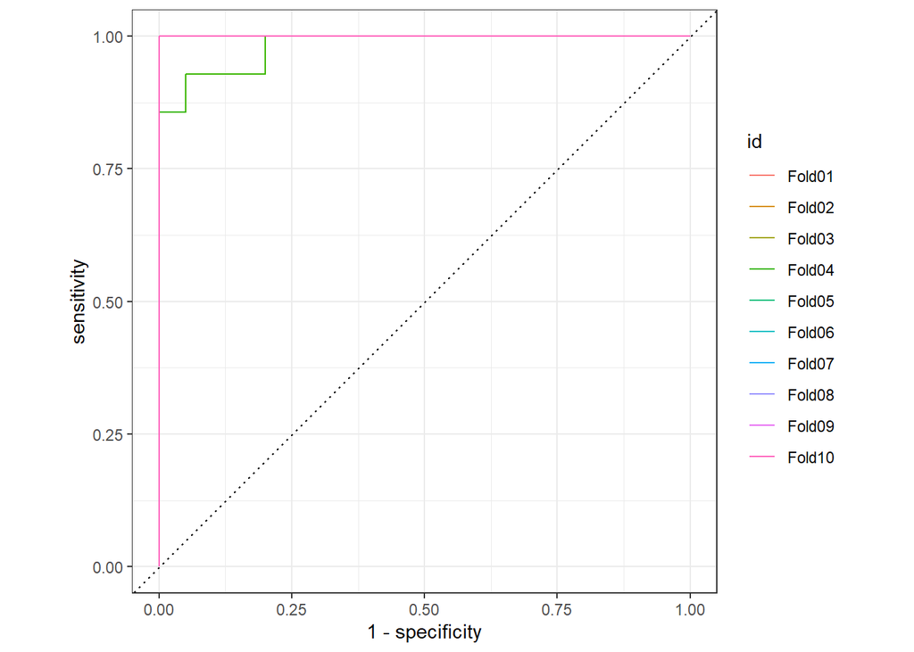

We tune the model’s $l_1$ penalty by creating a grid of 100 sensible values to try with `grid_regular()`. We learn that the value of $l_1$ that yields the best recall (𝜇 = 0.993) is 0.00059, and that this value also yields high ROC-AUC.

*Figure 4*

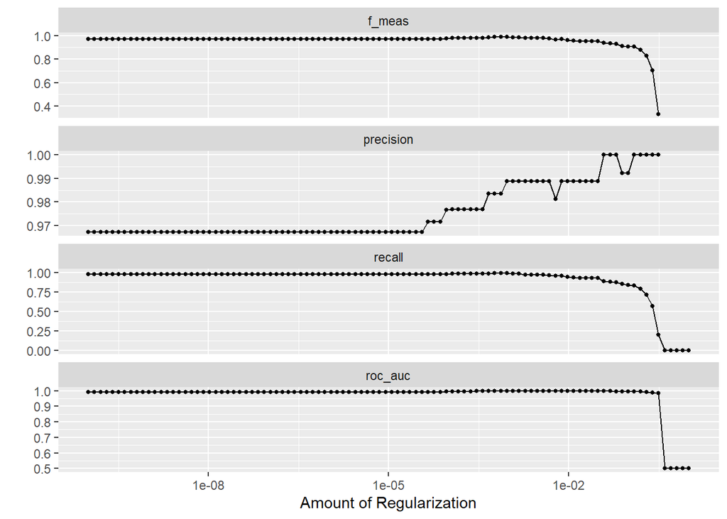

*Table 7*

| penalty | .metric | .estimator | mean | n | std_err | .config |
| --- | --- | --- | --- | --- | --- | --- |
| 0.0005857 | recall | binary | 0.9928571 | 10 | 0.0071429 | Preprocessor1_Model068 |
| 0.0007391 | recall | binary | 0.9928571 | 10 | 0.0071429 | Preprocessor1_Model069 |
| 0.0009326 | recall | binary | 0.9928571 | 10 | 0.0071429 | Preprocessor1_Model070 |
| 0.0001150 | recall | binary | 0.9861905 | 10 | 0.0092132 | Preprocessor1_Model061 |
| 0.0001451 | recall | binary | 0.9861905 | 10 | 0.0092132 | Preprocessor1_Model062 |

*Table 8*

| penalty | .config |
| --- | --- |
| 0.0005857 | Preprocessor1_Model068 |

Finally, we fit the lasso with the tuned penalty to the train data, and evaluate the performance on the test data. The model performs really well, with a high capability of distinguishing classes (ROC-AUC = 0.98), and a high recall (0.95) which means that the model is effective at capturing most positive cases, minimizing false negatives.

With the penalty parameter set at 0.00059, the majority of coefficients were effectively regularized to zero, resulting in the selection of 13 features considered most important for the classification.  
Among these, the variables that contributes the most to classify the breast mass as malignant are all those related to fractal dimension. The larger (mean and worst) and the more variations (SE) there are in fractal dimension, the more likely for it to be classified as malignant.  
On the other hand, higher values of smoothness (and variation in the smoothness), symmetry and concavity are associated with a more likely benign classification. These features seem to be characteristics observed in non-cancerous masses. Notably, smoothness (SE) and texture (SE), as well as fractal dimension (SE and mean) are among the features initially found to be insignificantly related to the target variable in a simple logistic regression.

*Table 9*

| term | estimate | penalty |
| --- | --- | --- |
| smoothness_se | -147.753341 | 0.0005857 |
| smoothness_worst | -90.227455 | 0.0005857 |
| symmetry_worst | -33.472900 | 0.0005857 |
| concavity_mean | -31.495602 | 0.0005857 |
| concave.points_worst | -25.082460 | 0.0005857 |
| concavity_worst | -4.915226 | 0.0005857 |
| radius_se | -2.810130 | 0.0005857 |
| radius_worst | -2.114635 | 0.0005857 |
| texture_worst | -0.629617 | 0.0005857 |
| texture_se | 3.192497 | 0.0005857 |
| (Intercept) | 61.345998 | 0.0005857 |
| fractal_dimension_worst | 86.552837 | 0.0005857 |
| fractal_dimension_se | 124.473450 | 0.0005857 |
| fractal_dimension_mean | 160.700094 | 0.0005857 |

*Table 10*

| .metric | .estimator | .estimate | .config |
| --- | --- | --- | --- |
| f_meas | binary | 0.9473684 | Preprocessor1_Model1 |
| precision | binary | 0.9418605 | Preprocessor1_Model1 |
| recall | binary | 0.9529412 | Preprocessor1_Model1 |
| roc_auc | binary | 0.9812423 | Preprocessor1_Model1 |

*Figure 5*

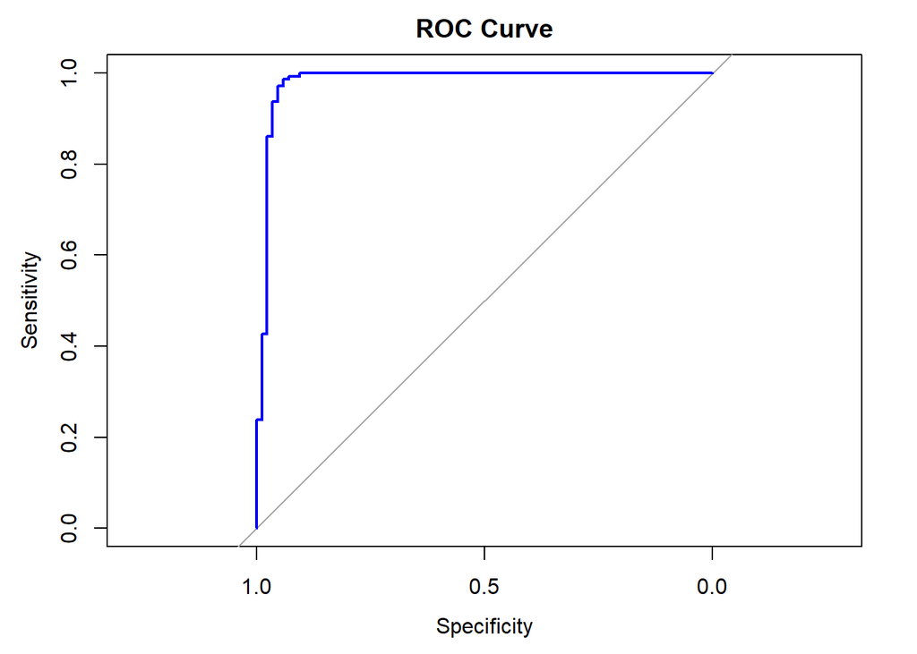

# Conclusion

Strikingly, both models yield almost the exact same performance, both being very effective in the binary classification task. It’s possible that both models converge to similar solutions during training and hyperparameter tuning. Overall, we managed to achieve a high level of recall with both models, minimizing false negatives, which was our goal.

*Figure 6*

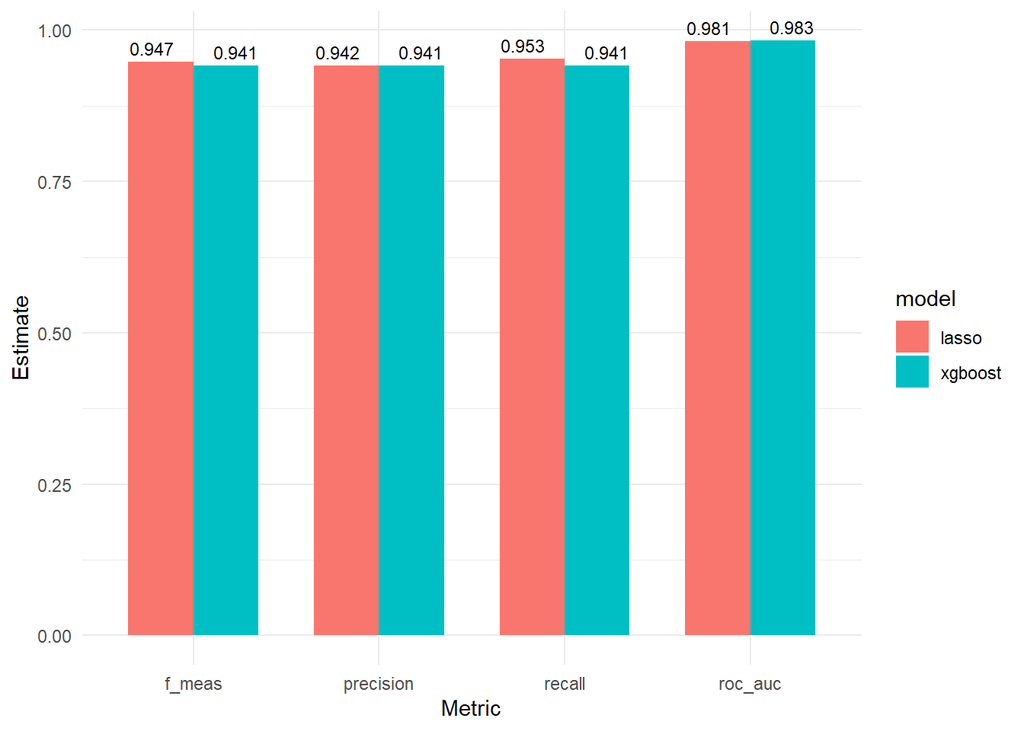

*Table 11*

| .metric | .estimator | .estimate | .config | model |
| --- | --- | --- | --- | --- |
| f_meas | binary | 0.9411765 | Preprocessor1_Model1 | xgboost |
| precision | binary | 0.9411765 | Preprocessor1_Model1 | xgboost |
| recall | binary | 0.9411765 | Preprocessor1_Model1 | xgboost |
| roc_auc | binary | 0.9826820 | Preprocessor1_Model1 | xgboost |
| f_meas | binary | 0.9473684 | Preprocessor1_Model1 | lasso |
| precision | binary | 0.9418605 | Preprocessor1_Model1 | lasso |
| recall | binary | 0.9529412 | Preprocessor1_Model1 | lasso |
| roc_auc | binary | 0.9812423 | Preprocessor1_Model1 | lasso |

In addition to their performance metrics, it’s important to consider the strengths and weaknesses of each model. As mentioned above, both models perform feature selection (albeit through different mechanism), which helps to identify which are the most important variables. While lasso’s coefficients provide interpretability, XGBoost is more of a black box. This also means however that XGBoost is more flexible and has the power to capture nonlinear relationships, while lasso cannot. This, however, does not seem to be important for this application. Finally, at least in this case, Lasso is computationally less expensive than XGBoost.  
Because of this and its slightly better performance we would choose the lasso regression model as final classification model.